# similarityComparison

William XQ Ngiam

2025-12-11

## Overview

This file is associated with the preprint titled [“Similarity judgments and visual working memory do not share the same cognitive representation”](https://osf.io/preprints/psyarxiv/fm9vz_v1) by William XQ Ngiam (Adelaide University) and Michael D Lee (University of California Irvine. This research project models the underlying psychological space in perceptual tasks, working memory tasks, and similarity judgment tasks.

The following model recovers the underlying psychological space for the orientation **similarity comparison** task in [Tomic and Bays (2024)](https://psycnet.apa.org/doi/10.1037/xlm0001172). In this task, two pairs of oriented lines (each randomly sampled from 0 to 180 degrees in 5 degree increments) is shown to the subject. The subject is asked which pair is more similar.

The following code builds a Bayesian Thurstonian model using JAGS. The underlying Thurstonian model is an attempt to recover the representation (much like multidimensional scaling) of the orientations. Then, this model could be used to predict performance on other tasks; such as a working memory task with these orientations.

### Requirements

The following files should be saved in your working directory:

- The data file (“oriSimData_clean.csv”) - [downloadable here](https://github.com/WilliamNgiam/orientationModeling/blob/main/data/oriSimData_clean.csv).
- The model text file (“similarityComparison_jags.txt”) - [downloadable here](https://github.com/WilliamNgiam/orientationModeling/blob/main/similarityComparison/similarityComparison_jags.txt).

You will also need to have installed JAGS on your device. The installer can be accessed here: [https://sourceforge.net/projects/mcmc-jags/files/]. This code was built using JAGS 4.3.2.

### Setup

```r
# Load required packages
library(R2jags) # v0.8-9
library(tidyverse) # v2.0.0
library(coda) # v0.19-4.1
library(ggmcmc) # v1.5.1.2

# Provide R session output
```

```r
# Set RNG seed for reproducibility
set.seed(42)
```

### Load data

```r
# Load in Tomic and Bays (2024) dataset
simData <- read_csv(paste0(getwd(),"/oriSimData_clean.csv"))

# Create intervals to match the Tomic and Bays (2024) perceptual task.
oriVals <- seq(0,2*pi,length.out = 73) # The orientation values in the dataset

simData <- simData %>%
  rowwise() %>%
  mutate(across(starts_with("pair"), ~ which.min(abs(.x-oriVals)),
                .names = "{col}_idx"))

# Assign data to vectors
a <- as.integer(simData$pairA_1_idx)
b <- as.integer(simData$pairA_2_idx)
c <- as.integer(simData$pairB_1_idx)
d <- as.integer(simData$pairB_2_idx)
y <- as.integer(1 - simData$response)

nTrials <- as.integer(length(simData$response))
nStimuli <- as.integer(72)

# Provide censoring initial values
xAinit <- vector()
xBinit <- vector()
xCinit <- vector()
xDinit <- vector()

for (t in 1:nTrials) {
  if (y[t] == 0) {
    xAinit[t] = 1.6
    xBinit[t] = 1.7
    xCinit[t] = 1.6
    xDinit[t] = 1.8
  } else {
    xAinit[t] = 1.6
    xBinit[t] = 1.8
    xCinit[t] = 1.6
    xDinit[t] = 1.7
  }
}
```

### Read in data for JAGS

```r
data.jags <- list("a","b","c","d","y","nTrials","nStimuli")
bayes.mod.params <- c("mu","sigma")
bayes.mod.inits <- function() {
  list("xA" = xAinit,
       "xB" = xBinit,
       "xC" = xCinit,
       "xD" = xDinit)
}
```

### Run model fit

```r
bayes.mod.fit <- jags(data = data.jags,
                      inits = bayes.mod.inits,
                      parameters.to.save = bayes.mod.params,
                      n.chains = 4,
                      n.iter = 8000,
                      n.burnin = 2000,
                      n.thin = 10,
                      model.file = paste0(getwd(),"/similarityComparison_jags.txt"))
```

```
## module glm loaded
```

```
## Compiling data graph
##    Initializing
##    Reading data back into data table
##
```

### Evaluate model

```r
print(bayes.mod.fit)
```

```
## Inference for Bugs model at "/Users/will.ngiam/Documents/1 RESEARCH/10 Projects/10.05 Generated MDS/simiJAGS/similarityComparison_jags.txt", fit using jags,
##  4 chains, each with 8000 iterations (first 2000 discarded), n.thin = 10
##  n.sims = 2400 iterations saved. Running time = 2847.461 secs
##          mu.vect sd.vect  2.5%   25%   50%   75% 97.5%  Rhat n.eff
## mu[1]      0.000   0.000 0.000 0.000 0.000 0.000 0.000 1.006   950
## mu[2]      0.012   0.011 0.000 0.004 0.009 0.018 0.039 1.004   630
## mu[3]      0.047   0.026 0.005 0.027 0.046 0.065 0.104 1.004   660
## mu[4]      0.044   0.026 0.003 0.023 0.041 0.061 0.101 1.015   210
## mu[5]      0.070   0.030 0.014 0.049 0.070 0.090 0.130 1.008   370
## mu[6]      0.123   0.031 0.064 0.104 0.123 0.143 0.188 1.008   330
## mu[7]      0.147   0.032 0.085 0.125 0.146 0.168 0.212 1.009   620
## mu[8]      0.216   0.032 0.154 0.195 0.216 0.237 0.279 1.015   170
## mu[9]      0.235   0.035 0.169 0.212 0.236 0.260 0.303 1.032    84
## mu[10]     0.279   0.034 0.215 0.255 0.279 0.302 0.343 1.015   180
## mu[11]     0.340   0.030 0.280 0.320 0.340 0.360 0.399 1.011   270
## mu[12]     0.393   0.032 0.329 0.371 0.392 0.414 0.456 1.018   160
## mu[13]     0.481   0.030 0.419 0.461 0.481 0.501 0.539 1.015   170
## mu[14]     0.530   0.031 0.470 0.509 0.530 0.551 0.587 1.002  1100
## mu[15]     0.581   0.030 0.521 0.561 0.582 0.601 0.637 1.005   830
## mu[16]     0.633   0.031 0.571 0.613 0.633 0.654 0.694 1.024   120
## mu[17]     0.734   0.030 0.677 0.714 0.735 0.755 0.793 1.007   360
## mu[18]     0.774   0.030 0.712 0.755 0.774 0.794 0.832 1.018   150
## mu[19]     0.800   0.029 0.743 0.781 0.799 0.820 0.859 1.010   250
## mu[20]     0.941   0.028 0.887 0.923 0.941 0.959 0.996 1.011   250
## mu[21]     0.953   0.028 0.900 0.934 0.952 0.972 1.011 1.018   150
## mu[22]     1.044   0.029 0.988 1.023 1.044 1.064 1.103 1.011   220
## mu[23]     1.049   0.030 0.990 1.029 1.049 1.069 1.109 1.002  1200
## mu[24]     1.082   0.030 1.024 1.062 1.080 1.101 1.142 1.004   730
## mu[25]     1.125   0.031 1.065 1.104 1.125 1.146 1.187 1.007   360
## mu[26]     1.195   0.031 1.134 1.174 1.196 1.216 1.254 1.011   230
## mu[27]     1.273   0.031 1.212 1.253 1.273 1.293 1.331 1.013   240
## mu[28]     1.262   0.031 1.202 1.241 1.262 1.282 1.324 1.006   600
## mu[29]     1.318   0.031 1.258 1.297 1.319 1.340 1.378 1.023   120
## mu[30]     1.354   0.033 1.284 1.333 1.354 1.376 1.416 1.008   310
## mu[31]     1.384   0.033 1.319 1.362 1.384 1.406 1.449 1.005   580
## mu[32]     1.414   0.034 1.350 1.392 1.414 1.436 1.484 1.016   200
## mu[33]     1.455   0.035 1.385 1.430 1.455 1.479 1.524 1.010   250
## mu[34]     1.467   0.034 1.401 1.443 1.466 1.490 1.536 1.008   320
## mu[35]     1.511   0.032 1.449 1.489 1.511 1.532 1.576 1.014   220
## mu[36]     1.557   0.031 1.496 1.535 1.556 1.577 1.617 1.005   930
```

[output cut: 30 more lines]

```
## mu[67]     3.020   0.032 2.955 2.999 3.020 3.041 3.083 1.011   240
## mu[68]     3.024   0.034 2.959 3.002 3.024 3.046 3.093 1.035    81
## mu[69]     3.073   0.030 3.014 3.052 3.073 3.094 3.129 1.004  1200
## mu[70]     3.057   0.034 2.991 3.034 3.058 3.081 3.120 1.021   130
## mu[71]     3.121   0.016 3.081 3.112 3.126 3.135 3.141 1.006   670
## mu[72]     3.126   0.014 3.090 3.119 3.129 3.136 3.141 1.004   730
## sigma      0.273   0.003 0.268 0.271 0.273 0.275 0.278 1.004   720
## deviance   0.000   0.000 0.000 0.000 0.000 0.000 0.000 1.000     1
##
## For each parameter, n.eff is a crude measure of effective sample size,
## and Rhat is the potential scale reduction factor (at convergence, Rhat=1).
##
## DIC info (using the rule: pV = var(deviance)/2)
## pV = 0.0 and DIC = 0.0
## DIC is an estimate of expected predictive error (lower deviance is better).
```

```r
bayes.mod.fit.mcmc <- as.mcmc(bayes.mod.fit)
summary(bayes.mod.fit.mcmc)
```

```
##
## Iterations = 2010:8000
## Thinning interval = 10
## Number of chains = 4
## Sample size per chain = 600
##
## 1. Empirical mean and standard deviation for each variable,
##    plus standard error of the mean:
##
##               Mean        SD  Naive SE Time-series SE
## deviance 0.000e+00 0.000e+00 0.000e+00      0.000e+00
## mu[1]    5.117e-07 2.857e-07 5.832e-09      6.083e-09
## mu[10]   2.785e-01 3.370e-02 6.879e-04      2.419e-03
## mu[11]   3.402e-01 3.018e-02 6.161e-04      2.154e-03
## mu[12]   3.926e-01 3.161e-02 6.452e-04      1.920e-03
## mu[13]   4.809e-01 2.974e-02 6.072e-04      1.642e-03
## mu[14]   5.297e-01 3.057e-02 6.240e-04      1.719e-03
## mu[15]   5.812e-01 2.955e-02 6.032e-04      1.889e-03
## mu[16]   6.334e-01 3.115e-02 6.359e-04      2.045e-03
## mu[17]   7.344e-01 3.044e-02 6.213e-04      1.605e-03
## mu[18]   7.737e-01 3.027e-02 6.179e-04      2.449e-03
## mu[19]   8.002e-01 2.914e-02 5.948e-04      1.671e-03
## mu[2]    1.209e-02 1.090e-02 2.225e-04      3.381e-04
## mu[20]   9.410e-01 2.798e-02 5.711e-04      1.416e-03
## mu[21]   9.531e-01 2.835e-02 5.786e-04      1.454e-03
## mu[22]   1.044e+00 2.942e-02 6.004e-04      1.562e-03
## mu[23]   1.049e+00 3.042e-02 6.209e-04      1.708e-03
## mu[24]   1.082e+00 2.958e-02 6.037e-04      1.509e-03
## mu[25]   1.125e+00 3.146e-02 6.421e-04      1.767e-03
## mu[26]   1.195e+00 3.097e-02 6.321e-04      1.941e-03
## mu[27]   1.273e+00 3.063e-02 6.253e-04      1.633e-03
## mu[28]   1.262e+00 3.092e-02 6.311e-04      1.761e-03
## mu[29]   1.318e+00 3.087e-02 6.301e-04      1.899e-03
## mu[3]    4.734e-02 2.592e-02 5.291e-04      1.161e-03
## mu[30]   1.354e+00 3.288e-02 6.711e-04      2.082e-03
## mu[31]   1.384e+00 3.324e-02 6.785e-04      1.883e-03
## mu[32]   1.414e+00 3.365e-02 6.868e-04      2.046e-03
## mu[33]   1.455e+00 3.492e-02 7.129e-04      2.263e-03
## mu[34]   1.467e+00 3.439e-02 7.020e-04      2.347e-03
## mu[35]   1.511e+00 3.217e-02 6.567e-04      1.979e-03
```

[output cut: 107 more lines]

```
## mu[62]   2.748e+00 2.791e+00 2.813e+00 2.838e+00 2.881e+00
## mu[63]   2.772e+00 2.812e+00 2.832e+00 2.854e+00 2.893e+00
## mu[64]   2.804e+00 2.845e+00 2.864e+00 2.885e+00 2.924e+00
## mu[65]   2.881e+00 2.922e+00 2.945e+00 2.966e+00 3.006e+00
## mu[66]   2.880e+00 2.921e+00 2.945e+00 2.968e+00 3.015e+00
## mu[67]   2.955e+00 2.999e+00 3.020e+00 3.041e+00 3.083e+00
## mu[68]   2.959e+00 3.002e+00 3.024e+00 3.046e+00 3.093e+00
## mu[69]   3.014e+00 3.052e+00 3.073e+00 3.094e+00 3.129e+00
## mu[7]    8.535e-02 1.247e-01 1.465e-01 1.677e-01 2.124e-01
## mu[70]   2.991e+00 3.034e+00 3.058e+00 3.081e+00 3.120e+00
## mu[71]   3.081e+00 3.112e+00 3.126e+00 3.135e+00 3.141e+00
## mu[72]   3.090e+00 3.119e+00 3.129e+00 3.136e+00 3.141e+00
## mu[8]    1.538e-01 1.954e-01 2.162e-01 2.373e-01 2.787e-01
## mu[9]    1.688e-01 2.118e-01 2.357e-01 2.599e-01 3.029e-01
## sigma    2.677e-01 2.710e-01 2.730e-01 2.747e-01 2.783e-01
```

### Plots

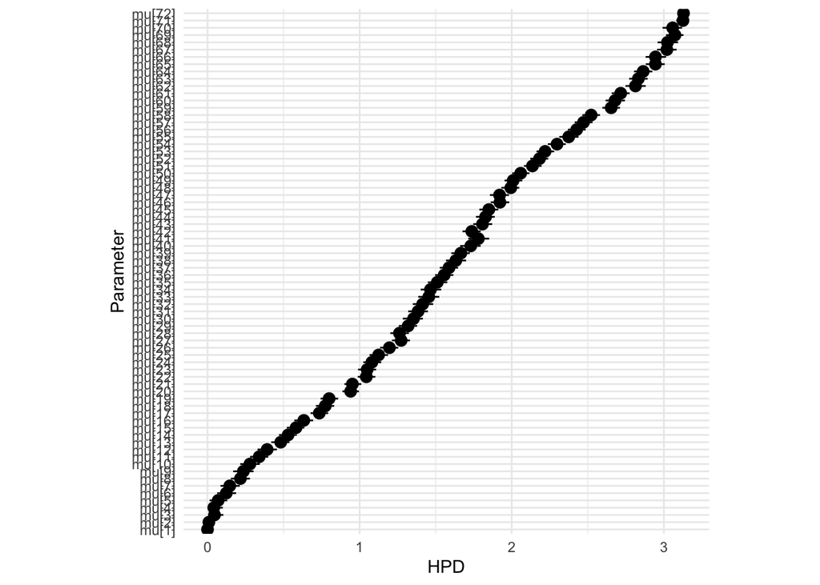

```r
# Convert into ggmcmc object
bayes.mod.fit.gg <- ggs(bayes.mod.fit.mcmc)

ggs_caterpillar(bayes.mod.fit.gg,
                thick_ci = c(0.45,0.55),
                family = "mu",
                sort = FALSE) +
  theme_minimal() +
  theme(aspect.ratio = 1)
```

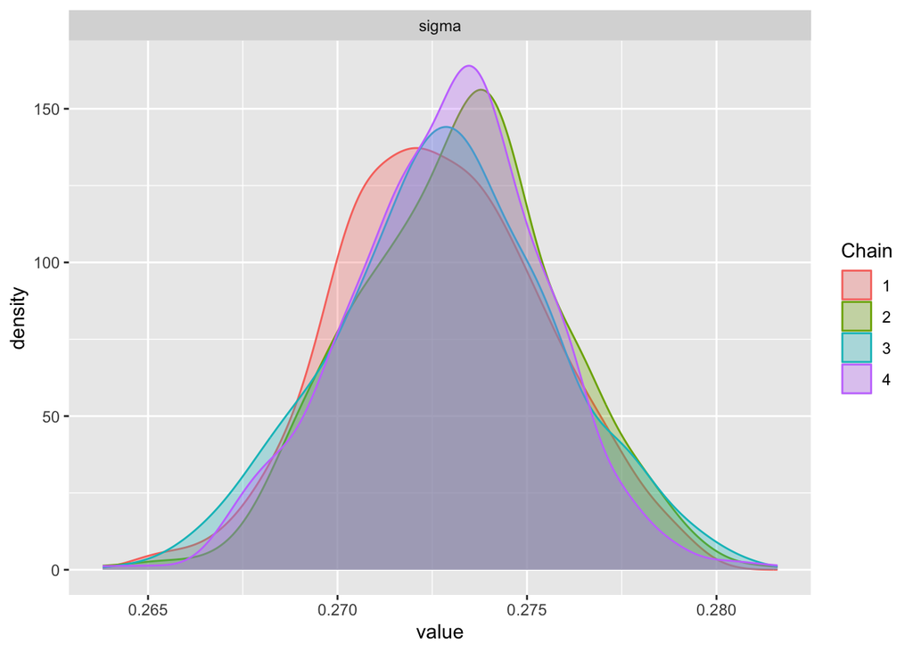

```r
ggs_density(bayes.mod.fit.gg,
            family = "sigma")
```